# Figure 1

John Favate

2021-01-12 11:51:38

```r
# Prevent printing of warnings and such in the HTML
knitr::opts_chunk$set(warning = FALSE, message = FALSE, fig.align = "center")
```

```r
library(tidyverse)
library(patchwork)
library(ggpubr)
library(ggpointdensity)
library(ggridges)
library(ggrepel)
library(png)
library(grid)
```

### Panel A

The schematic figure loaded as a png and then placed atop a graph of nothing.

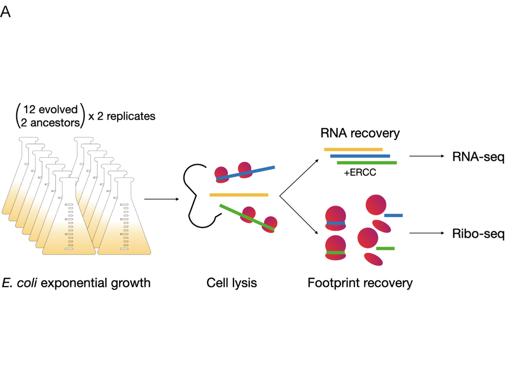

```r
png.a <- rasterGrob(readPNG("../../figures/b_schematic_figures.png"), interpolate = TRUE)

pa <- ggplot(mtcars, aes(hp, mpg))+
  annotation_custom(grob = png.a, xmin = -Inf, xmax = Inf, ymin = -Inf, ymax = Inf)+
  labs(x = NULL, y = NULL, title = "A")+
  theme_void()+
  theme(text = element_text(size = 13))

pa
```

### Panel B

```r
size.df <- read_csv("../../data_frames/table_s3_cell_size.csv") %>%
  mutate(volume = (pi/4)*(SHAPE.width.mean^2)*(SHAPE.length-(SHAPE.length/3)),
         mutator = ifelse(line %in% c("Ara+6", "Ara+3", "Ara-4", "Ara-2", "Ara-1", "Ara-3"), TRUE, FALSE),
         age = ifelse(grepl("REL", line), "old", "young")) %>%
  filter(line != "Ara+6")

head(size.df)
```

| NAME | ASSOCIATION | EXPERIMENT | line | repl | LOCATION | POSITION | SHAPE | SHAPE.area | SHAPE.length | SHAPE.perimeter | SHAPE.width.mean | ZSCORE | volume | mutator | age |
| --- | --- | --- | --- | --- | --- | --- | --- | --- | --- | --- | --- | --- | --- | --- | --- |
| b1 | 0 | Lenski strains | Ara-1 | 1 | (x=4.82 y=105.10) | 1 | 1 | 3.757877 | 4.114437 | 9.222536 | 0.9779713 | 7.840422 | 2.060446 | TRUE | young |
| b2 | 0 | Lenski strains | Ara-1 | 1 | (x=18.18 y=100.41) | 1 | 1 | 4.358836 | 3.657374 | 8.694816 | 1.3199991 | 7.953618 | 3.336686 | TRUE | young |
| b3 | 0 | Lenski strains | Ara-1 | 1 | (x=19.35 y=50.90) | 1 | 1 | 3.758610 | 3.768445 | 8.722535 | 1.0684808 | 8.003543 | 2.252653 | TRUE | young |
| b4 | 0 | Lenski strains | Ara-1 | 1 | (x=26.37 y=27.25) | 1 | 1 | 3.863350 | 3.318992 | 8.019637 | 1.2938564 | 7.822563 | 2.909223 | TRUE | young |
| b5 | 0 | Lenski strains | Ara-1 | 1 | (x=32.93 y=43.78) | 1 | 1 | 4.285527 | 4.454953 | 9.957407 | 1.0301193 | 7.630537 | 2.475237 | TRUE | young |
| b6 | 0 | Lenski strains | Ara-1 | 1 | (x=40.12 y=43.73) | 1 | 1 | 3.864248 | 3.739339 | 8.698900 | 1.1149777 | 7.647562 | 2.434029 | TRUE | young |

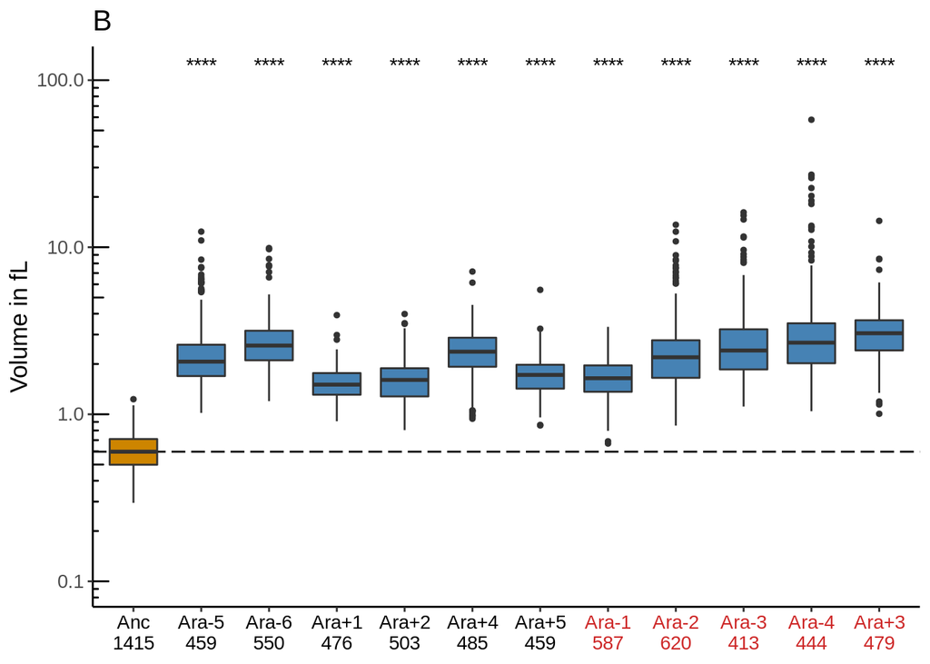

```r
# the data frame for figure 2
bdf <- size.df %>%
  mutate(line = ifelse(grepl("REL", line), "Anc", line))

# Get the median ancestral volume for a dotted line
anc.median.volume <- bdf %>%
  filter(line == "Anc") %>%
  summarise(median.volume = median(volume)) %>%
  pull(median.volume)

# factor the lines in anc, mut, non-mut order
mut.levels <- bdf %>%
  dplyr::select(line, mutator) %>%
  arrange(mutator, line) %>%
  unique() %>%
  pull(line)

bdf$line <- factor(bdf$line, levels = mut.levels)

# set mut colors for x axis labels
mut.colors.a <- c("black", rep("black", 6), rep("firebrick3", 5))

# get new x labs with the number of cells imaged
newxlabs.volume <- bdf %>%
  group_by(line) %>%
  tally() %>%
  ungroup() %>%
  mutate(newlab = paste0(line, "\n", n)) %>%
  pull(newlab)

# define the relationship between symbols and p values
symnum.args <- list(cutpoints = c(0, 0.0001, 0.001, 0.01, 0.05, 1),
                    symbols = c("****", "***", "**", "*", "ns"))

pb <- bdf %>%
  ggplot(., aes(line, volume, fill = age))+
  geom_hline(aes(yintercept = anc.median.volume), linetype = 5)+
  geom_boxplot(outlier.size = 1, width = .7)+
  labs(x = NULL,
       y = "Volume in fL",
       title = "B")+
  scale_x_discrete(labels = newxlabs.volume)+
  stat_compare_means(ref.group = "Anc", aes(label = ..p.signif..), symnum.args = symnum.args, method = "t.test")+
  theme(text = element_text(size = 13),
        panel.background = element_blank(),
        axis.line = element_line(color = "black"),
        axis.text.x = element_text(color = mut.colors.a))+
  scale_y_log10(limits = c(.1, 112))+
  annotation_logticks(sides = "l")+
  scale_fill_manual(values = c("orange3", "steelblue"), guide = FALSE)

pb
```

Add the external images

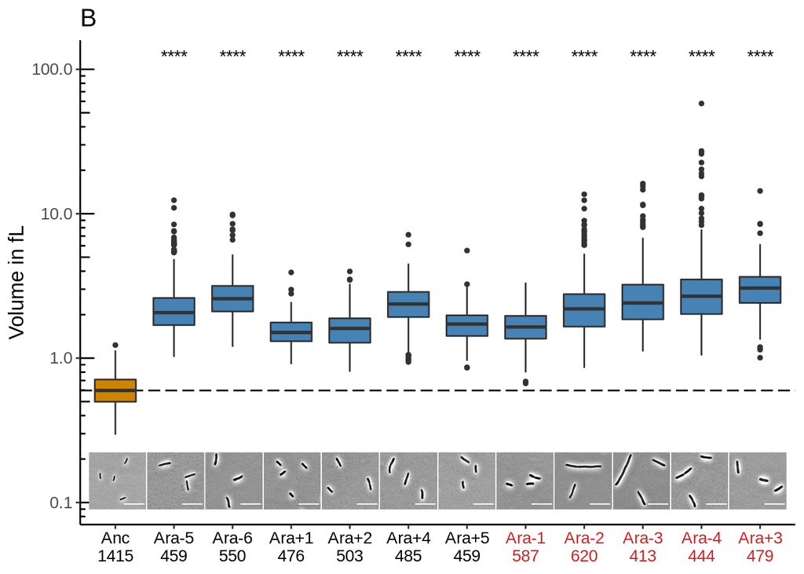

```r
png.b <- rasterGrob(readPNG("../../figures/b_bac_images2.png"), interpolate = TRUE)

(pb2 <- pb + annotation_custom(png.b, xmin = .55, xmax = 12.45, ymin = -1.7, ymax = 0))
```

### Panel C

Example linear model showing relationship between predicted number of ERCC added and it’s TPM in the sample.

```r
ercc.df <- read_csv("../../data_frames/table_s5_ercc_molecules_per_sample.csv")

head(ercc.df)
```

| repl | seqtype | line | target_id | est_counts | eff_length | length | tpm | subgroup | mix1.conc.attomols.ul | mix2.conc.attomols.ul | expected.fc.ratio | log2(mix1.over.mix2) | dilution | amount.added | molecules_of_seq |
| --- | --- | --- | --- | --- | --- | --- | --- | --- | --- | --- | --- | --- | --- | --- | --- |
| rep1 | ribo | Ara-1 | ERC_00002 | 31 | 1037 | 1061 | 2.9636398 | D | 1.500000e+04 | 3.000000e+04 | 0.50 | -1.00 | 10 | 0.761 | 6.874274e+08 |
| rep1 | ribo | Ara-1 | ERC_00003 | 4 | 999 | 1023 | 0.3969511 | D | 9.375000e+02 | 1.875000e+03 | 0.50 | -1.00 | 10 | 0.761 | 4.296421e+07 |
| rep1 | ribo | Ara-1 | ERC_00004 | 5 | 499 | 523 | 0.9933721 | A | 7.500000e+03 | 1.875000e+03 | 4.00 | 2.00 | 10 | 0.761 | 3.437137e+08 |
| rep1 | ribo | Ara-1 | ERC_00009 | 1 | 960 | 984 | 0.1032693 | B | 9.375000e+02 | 9.375000e+02 | 1.00 | 0.00 | 10 | 0.761 | 4.296421e+07 |
| rep1 | ribo | Ara-1 | ERC_00012 | 0 | 970 | 994 | 0.0000000 | C | 1.144409e-01 | 1.716614e-01 | 0.67 | -0.58 | 10 | 0.761 | 5.244655e+03 |
| rep1 | ribo | Ara-1 | ERC_00013 | 0 | 784 | 808 | 0.0000000 | D | 9.155273e-01 | 1.831055e+00 | 0.50 | -1.00 | 10 | 0.761 | 4.195724e+04 |

Plot for a single line

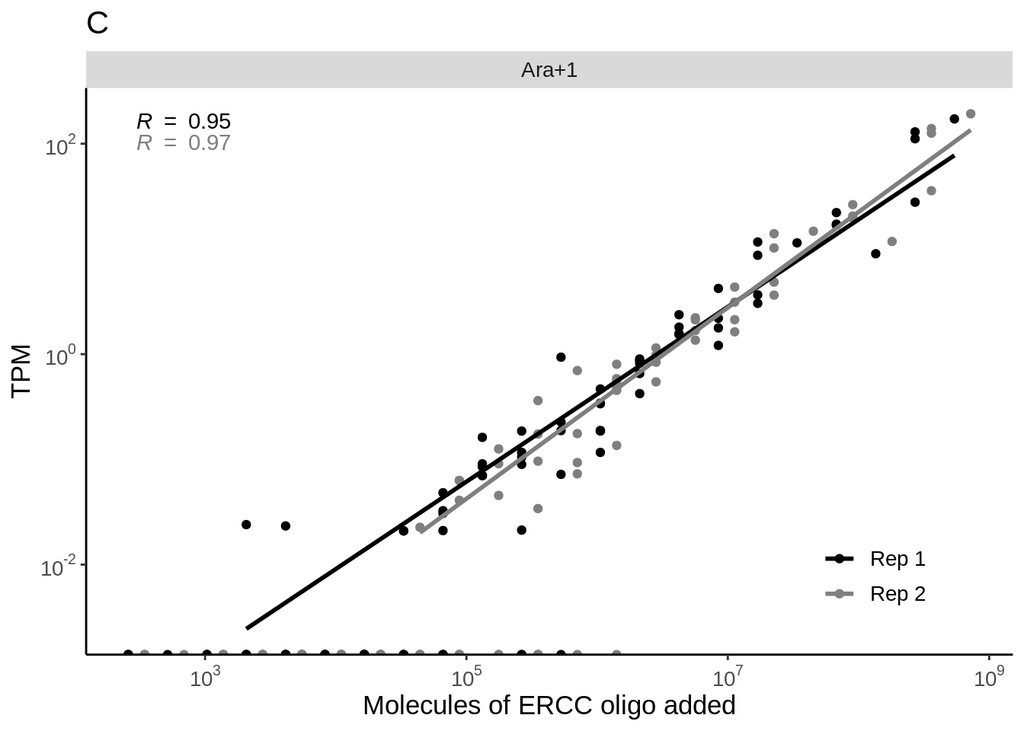

```r
pc <- ercc.df %>%
  filter(line == "Ara+1" & seqtype == "rna") %>%
  ggplot(., aes(molecules_of_seq, tpm, color = repl))+
  geom_point()+
  geom_smooth(method = "lm", se = FALSE)+
  stat_cor(aes(label = ..r.label..), show.legend = FALSE, label.x.npc = .01, label.y.npc = .99)+
  scale_y_log10(breaks = c(10^-2, 10^0, 10^2), labels = scales::trans_format("log10", scales::math_format(10^.x)))+
  scale_x_log10(breaks = c(1e3, 1e5, 1e7, 1e9), labels = scales::trans_format("log10", scales::math_format(10^.x)))+
  theme(panel.background = element_blank(),
        axis.line = element_line(color = "black"),
        text = element_text(size = 13),
        legend.position = c(.85, .15),
        legend.key = element_blank(),
        legend.background = element_blank())+
  scale_color_manual(values = c("black", "grey50"),
                     name = NULL,
                     labels = c("Rep 1", "Rep 2"))+
  labs(y = "TPM",
       x = "Molecules of ERCC oligo added",
       title = "C")+
  facet_wrap(~line)

pc
```

### Panel D

Scatterplot of changes in absolute amounts.

```r
mols.per.cfu.df <- read_csv("../../data_frames/table_s6_mRNAs_per_cfu.csv")

head(mols.per.cfu.df)
```

| line | repl | target_id | tpm | seqtype | intercept | slope | n_molecules | dilution_1_over | counts_1 | counts_2 | counts_3 | cells_in_50ml_1 | cells_in_50ml_2 | cells_in_50ml_3 | avg_cells_in_50ml | volume_of_lysate_ul | volume_of_lysate_used_ul | prop_of_lysate | cells_after_lysate_clarification | volume_after_clarifiation | cells_used_for_extraction | cells_after_extraction | proportion_of_cells_used | cells_1_final | cells_2_final | cells_3_final | mean_cells_final | n_mol_per_cfu |
| --- | --- | --- | --- | --- | --- | --- | --- | --- | --- | --- | --- | --- | --- | --- | --- | --- | --- | --- | --- | --- | --- | --- | --- | --- | --- | --- | --- | --- |
| Ara-1 | rep1 | ECB_00001 | 56.179858 | rna | 6.409052 | 0.9724212 | 128938162 | 1e+05 | 123 | 63 | 57 | 6.15e+08 | 3.15e+08 | 2.85e+08 | 4.05e+08 | 650 | 550 | 0.8461538 | 342692308 | 29.24 | 18218769 | 15182308 | 0.03748718 | 23054615 | 11808462 | 10683846 | 15182308 | 8.492659 |
| Ara-1 | rep1 | ECB_00002 | 31.412891 | rna | 6.409052 | 0.9724212 | 73260799 | 1e+05 | 123 | 63 | 57 | 6.15e+08 | 3.15e+08 | 2.85e+08 | 4.05e+08 | 650 | 550 | 0.8461538 | 342692308 | 29.24 | 18218769 | 15182308 | 0.03748718 | 23054615 | 11808462 | 10683846 | 15182308 | 4.825406 |
| Ara-1 | rep1 | ECB_00003 | 23.354498 | rna | 6.409052 | 0.9724212 | 54914206 | 1e+05 | 123 | 63 | 57 | 6.15e+08 | 3.15e+08 | 2.85e+08 | 4.05e+08 | 650 | 550 | 0.8461538 | 342692308 | 29.24 | 18218769 | 15182308 | 0.03748718 | 23054615 | 11808462 | 10683846 | 15182308 | 3.616987 |
| Ara-1 | rep1 | ECB_00004 | 27.902329 | rna | 6.409052 | 0.9724212 | 65286533 | 1e+05 | 123 | 63 | 57 | 6.15e+08 | 3.15e+08 | 2.85e+08 | 4.05e+08 | 650 | 550 | 0.8461538 | 342692308 | 29.24 | 18218769 | 15182308 | 0.03748718 | 23054615 | 11808462 | 10683846 | 15182308 | 4.300172 |
| Ara-1 | rep1 | ECB_00005 | 10.981519 | rna | 6.409052 | 0.9724212 | 26364187 | 1e+05 | 123 | 63 | 57 | 6.15e+08 | 3.15e+08 | 2.85e+08 | 4.05e+08 | 650 | 550 | 0.8461538 | 342692308 | 29.24 | 18218769 | 15182308 | 0.03748718 | 23054615 | 11808462 | 10683846 | 15182308 | 1.736507 |
| Ara-1 | rep1 | ECB_00006 | 6.499629 | rna | 6.409052 | 0.9724212 | 15831508 | 1e+05 | 123 | 63 | 57 | 6.15e+08 | 3.15e+08 | 2.85e+08 | 4.05e+08 | 650 | 550 | 0.8461538 | 342692308 | 29.24 | 18218769 | 15182308 | 0.03748718 | 23054615 | 11808462 | 10683846 | 15182308 | 1.042760 |

Compute an ancestral average molecules_per_cfu from the 4 ancestral samples.

```r
anc.means <- mols.per.cfu.df %>%
  filter(line %in% c("REL606", "REL607")) %>%
  group_by(target_id) %>%
  summarise(anc_mean_mol_per_cfu = mean(n_mol_per_cfu))

head(anc.means)
```

| target_id | anc_mean_mol_per_cfu |
| --- | --- |
| ECB_00001 | 2.1687499 |
| ECB_00002 | 1.2427422 |
| ECB_00003 | 1.2444852 |
| ECB_00004 | 1.2986595 |
| ECB_00005 | 0.4354098 |
| ECB_00006 | 0.1033755 |

The data frame for the plot, shows the average molecules per cfu for one line compared to that of the ancestors.

```r
ddf <- mols.per.cfu.df %>%
  filter(line == "Ara-1") %>%
  group_by(line, target_id) %>%
  summarise(mean_mol_per_cfu = mean(n_mol_per_cfu)) %>%
  left_join(anc.means, by = "target_id")

head(ddf)
```

| line | target_id | mean_mol_per_cfu | anc_mean_mol_per_cfu |
| --- | --- | --- | --- |
| Ara-1 | ECB_00001 | 13.7292766 | 2.1687499 |
| Ara-1 | ECB_00002 | 5.9635593 | 1.2427422 |
| Ara-1 | ECB_00003 | 4.8036900 | 1.2444852 |
| Ara-1 | ECB_00004 | 5.2364065 | 1.2986595 |
| Ara-1 | ECB_00005 | 1.9585593 | 0.4354098 |
| Ara-1 | ECB_00006 | 0.9515607 | 0.1033755 |

Make the plot.

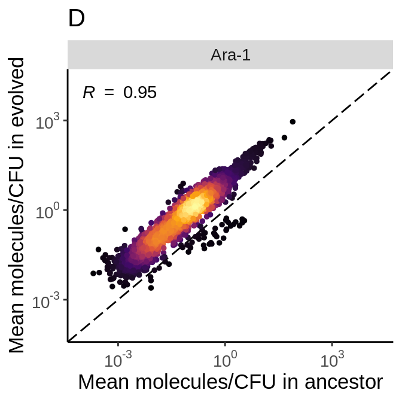

```r
pd <- ddf %>%
  ggplot(., aes(anc_mean_mol_per_cfu, mean_mol_per_cfu))+
  geom_abline(aes(slope = 1, intercept= 0), linetype = 5)+
  geom_pointdensity(size = 1)+
  scale_x_log10(limits = c(1e-4, 2e4), breaks = c(1e-3, 1e0, 1e3), labels = scales::trans_format("log10", scales::math_format(10^.x)))+
  scale_y_log10(limits = c(1e-4, 2e4), breaks = c(1e-3, 1e0, 1e3), labels = scales::trans_format("log10", scales::math_format(10^.x)))+
  theme(panel.background = element_blank(),
        axis.line = element_line(color = "black"),
        text = element_text(size = 13))+
  labs(x = "Mean molecules/CFU in ancestor",
       y = "Mean molecules/CFU in evolved",
       title = "D")+
  facet_wrap(~line)+
  scale_color_viridis_c(option = "B",
                        name = "Neighboring\npoints",
                        guide = FALSE)+
  stat_cor(aes(label = ..r.label..))

pd
```

### Panel E

This panel will be a ridge lines plot showing the fold change in molecules per cfu between replicates, and also from each evolved line to the ancestors. First, get the number comparing replicates.

```r
rep.compares <- mols.per.cfu.df %>%                            #
  split(.$line) %>%                                            # for each line
  map(function(x){                                             #
    x %>%                                                      #
      select(line, repl, target_id, n_mol_per_cfu) %>%         # retain the columns
      pivot_wider(names_from = repl,                           # reshape the data
                  values_from = n_mol_per_cfu) %>%             #
      mutate(ratio = rep1/rep2) %>%                            # find ratio between replicates
      filter(!is.na(ratio) & !is.infinite(ratio) & ratio != 0) # keep non-zero numbers
  }) %>%
  bind_rows() %>%                                              # put them back together
  select(line, ratio)                                          # retain these rows

head(rep.compares)
```

| line | ratio |
| --- | --- |
| Ara-1 | 0.4477858 |
| Ara-1 | 0.6794708 |
| Ara-1 | 0.6037979 |
| Ara-1 | 0.6966502 |
| Ara-1 | 0.7963396 |
| Ara-1 | 1.2120029 |

Next, find the ratio between the mean from the evolved lines to the mean of the ancestors.

```r
evo.to.anc.ratios <- mols.per.cfu.df %>%                      #
  filter(grepl("Ara", line)) %>%
  group_by(line, target_id) %>%                               # for each gene in each line
  summarise(mean_mol_per_cfu = mean(n_mol_per_cfu)) %>%       # get the average of the two reps
  left_join(., anc.means) %>%                                 # add a col for ancestral mean
  mutate(ratio = mean_mol_per_cfu / anc_mean_mol_per_cfu) %>% # find the evo/anc ratio
  select(line, ratio) %>%                                     # retain these cols
  filter(!is.na(ratio) & !is.infinite(ratio) & ratio != 0)    # keep non-zero numbers

head(evo.to.anc.ratios)
```

| line | ratio |
| --- | --- |
| Ara-1 | 6.330502 |
| Ara-1 | 4.798710 |
| Ara-1 | 3.859982 |
| Ara-1 | 4.032163 |
| Ara-1 | 4.498198 |
| Ara-1 | 9.204896 |

```r
combo.df <- bind_rows("intrarep" = rep.compares, "evoanc" = evo.to.anc.ratios, .id = "comp")

head(combo.df)
```

| comp | line | ratio |
| --- | --- | --- |
| intrarep | Ara-1 | 0.4477858 |
| intrarep | Ara-1 | 0.6794708 |
| intrarep | Ara-1 | 0.6037979 |
| intrarep | Ara-1 | 0.6966502 |
| intrarep | Ara-1 | 0.7963396 |
| intrarep | Ara-1 | 1.2120029 |

Then make a graph

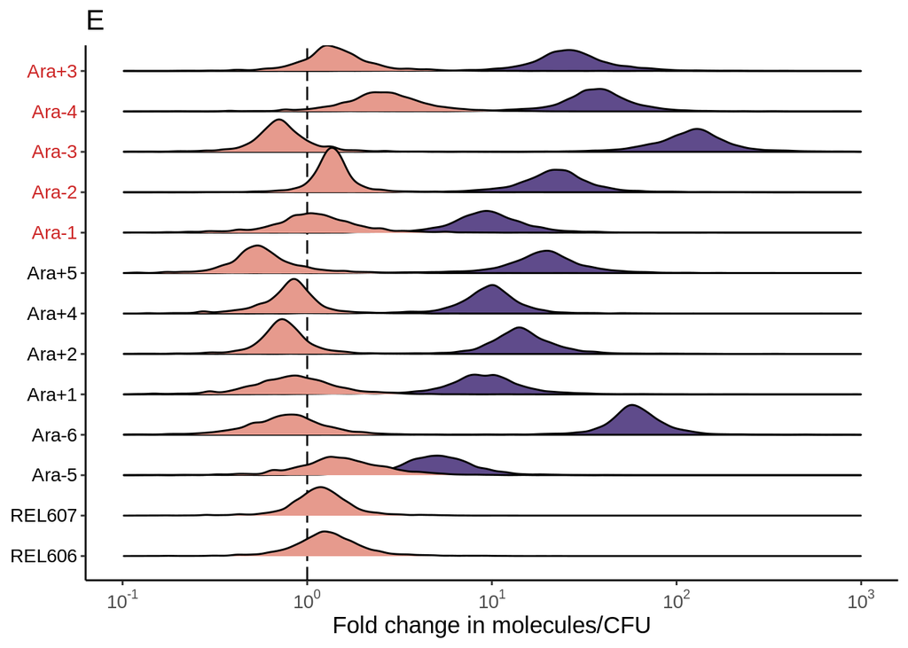

```r
# line order on y axis
combo.df$line <- factor(combo.df$line, levels = c("REL606", "REL607", mut.levels))

# mutator colors
mut.colors.d <- c(rep("black", 8), rep("firebrick3", 5))

# the plot
pe <- combo.df %>%
  ggplot(., aes(x = ratio, y = line, fill = comp))+
  geom_vline(aes(xintercept = 1), linetype = 5)+
  geom_density_ridges(scale = 1.1)+
  scale_x_log10(limits = c(1e-1, 1e3), labels = scales::trans_format("log10", scales::math_format(10^.x)))+
  theme(panel.background = element_blank(),
        axis.line = element_line(color = "black"),
        text = element_text(size = 13),
        axis.text.y = element_text(color = mut.colors.d))+
  labs(x = "Fold change in molecules/CFU",
       y = NULL,
       title = "E")+
  scale_fill_manual(values = c("#5F4B8BFF", "#E69A8DFF"),
                    name = NULL,
                    labels = c("Evolved/Ancestor", "Rep1/Rep2"),
                    guide = FALSE)

pe
```

t-tests to show that those are indeed different

```r
combo.df %>%
  filter(!(grepl("REL", line))) %>%
  compare_means(ratio~comp, method = "t.test", group.by = "line", data = .)
```

| line | .y. | group1 | group2 | p | p.adj | p.format | p.signif | method |
| --- | --- | --- | --- | --- | --- | --- | --- | --- |
| Ara-1 | ratio | intrarep | evoanc | 0.000000e+00 | 0.0e+00 | < 2e-16 | **** | T-test |
| Ara-2 | ratio | intrarep | evoanc | 0.000000e+00 | 0.0e+00 | < 2e-16 | **** | T-test |
| Ara-3 | ratio | intrarep | evoanc | 1.502434e-11 | 1.5e-11 | 1.5e-11 | **** | T-test |
| Ara-4 | ratio | intrarep | evoanc | 0.000000e+00 | 0.0e+00 | < 2e-16 | **** | T-test |
| Ara-5 | ratio | intrarep | evoanc | 0.000000e+00 | 0.0e+00 | < 2e-16 | **** | T-test |
| Ara-6 | ratio | intrarep | evoanc | 0.000000e+00 | 0.0e+00 | < 2e-16 | **** | T-test |
| Ara+1 | ratio | intrarep | evoanc | 1.174961e-41 | 2.3e-41 | < 2e-16 | **** | T-test |
| Ara+2 | ratio | intrarep | evoanc | 0.000000e+00 | 0.0e+00 | < 2e-16 | **** | T-test |
| Ara+3 | ratio | intrarep | evoanc | 0.000000e+00 | 0.0e+00 | < 2e-16 | **** | T-test |
| Ara+4 | ratio | intrarep | evoanc | 2.004495e-219 | 6.0e-219 | < 2e-16 | **** | T-test |

[output cut: 1 more lines]

### Panel F

Correlation between size and molecules per cfu. Get median/mean sizes

```r
(avg.sizes <- size.df %>%
  group_by(line) %>%
  summarise(median_volume = median(volume),
            mean_volume = mean(volume)) %>%
  ungroup())
```

| line | median_volume | mean_volume |
| --- | --- | --- |
| Ara-1 | 1.6433109 | 1.6764270 |
| Ara-2 | 2.1939795 | 2.3877807 |
| Ara-3 | 2.4092383 | 2.7763800 |
| Ara-4 | 2.6828862 | 3.4583541 |
| Ara-5 | 2.0660303 | 2.3781311 |
| Ara-6 | 2.5787134 | 2.7012935 |
| Ara+1 | 1.5052063 | 1.5580238 |
| Ara+2 | 1.6054778 | 1.6340959 |
| Ara+3 | 3.0553313 | 3.1626017 |
| Ara+4 | 2.3697803 | 2.4221007 |

[output cut: 3 more lines]

Get total RNA per cfu for each line

```r
mols.cfu.per.line <- mols.per.cfu.df %>%
  group_by(repl, line, seqtype) %>%
  summarise(total_rna_per_cfu = sum(n_mol_per_cfu)) %>%
  ungroup()
```

Join those and find the average between replicates.

```r
fdf <- left_join(avg.sizes, mols.cfu.per.line, by = "line") %>%                                    #
  group_by(line, median_volume) %>%                                                                  # for each line
  summarise(rna = mean(total_rna_per_cfu, na.rm = TRUE)) %>%                                       # find mean of total RNA per CFU between reps
  ungroup() %>%                                                                                    #
  mutate(mutator = ifelse(line %in% c("Ara-1", "Ara-2", "Ara-3", "Ara+3", "Ara-4"), "mut", "not")) # add mutator info
```

Plot.

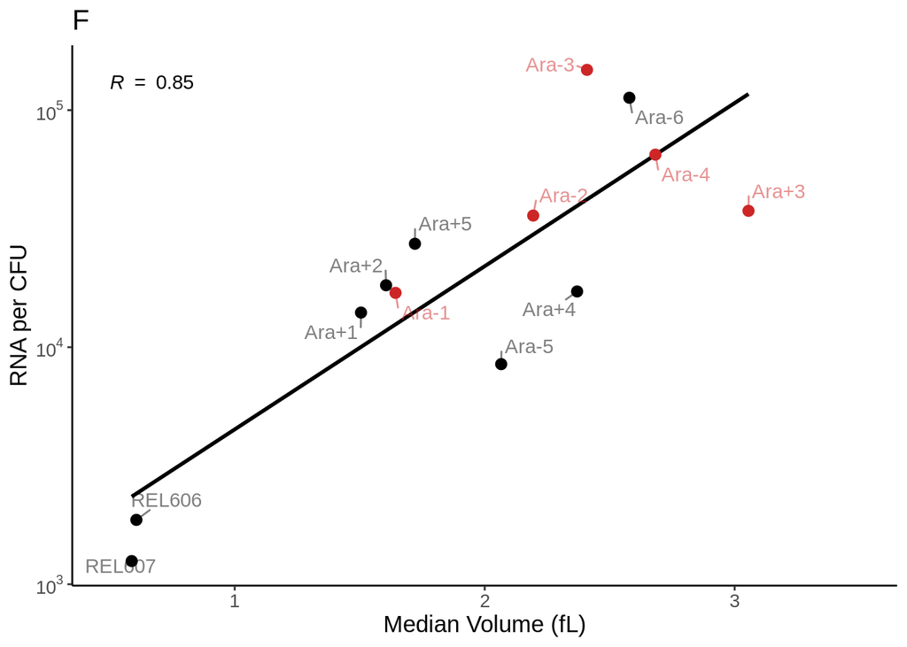

```r
set.seed(5)

pf <- fdf %>%
  ggplot(., aes(median_volume, rna, label = line, color = mutator))+
  geom_smooth(method = "lm", inherit.aes = FALSE, aes(x = median_volume, y = rna), se = FALSE, color = "black")+
  geom_point(size = 2.5)+
  geom_text_repel(min.segment.length = .00001, box.padding = .5, alpha = .5, seed = 1)+
  stat_cor(aes(label = ..r.label.., x = median_volume, y = rna), inherit.aes = FALSE)+
  theme(panel.background = element_blank(),
        axis.line = element_line(color = "black"),
        text = element_text(size = 13))+
  labs(x = "Median Volume (fL)",
       y = "RNA per CFU",
       title = "F")+
  scale_color_manual(values = c("firebrick3", "black"), guide = FALSE)+
  scale_y_log10(labels = scales::trans_format("log10", scales::math_format(10^.x)))+
  scale_x_continuous(limits = c(.5, 3.5))

pf
```

### Final figure

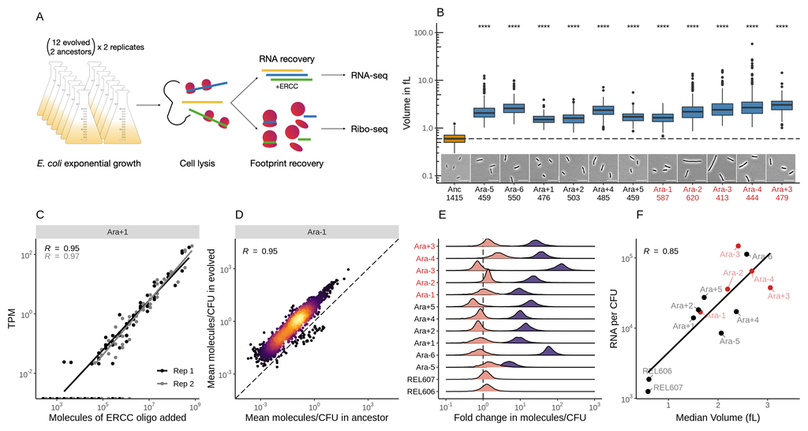

```r
top <- pa | pb2

bottom <- (pc | pd | pe | pf)

(ff <- top / bottom)
```

Save it

```r
ggsave(plot = ff, filename = "../../figures/b_fig_1.pdf", width = 15, height = 8)

ggsave(plot = ff, filename = "../../figures/b_fig_1.png", dpi = 300, width = 15, height = 8)
```